# Youtube Category Classification

**Author: Vincenzo Altomare**

**matr: 236028**

**Progetto di Data Mining A.A. 2021-2022**

# Introduzione

Youtube è una delle piattaforme di condivisione video più utilizzate al mondo, la quale mantiene un elenco dei video più di tendenza sulla piattaforma. Per determinare i video più di tendenza dell'anno, YouTube utilizza una combinazione di fattori tra cui la misurazione delle interazioni degli utenti, come numero di visualizzazioni, mi piace e commenti. Inoltre, è presente una classificazione dei video per categorie. Il dataset scelto racchiude una serie di video raccolti nell'arco di diversi mesi e lo scopo di questo lavoro è quello di classificare i diversi video in categorie di appartenenza tramite alcuni modelli di machine learning utili alla classificazione.

Il dataset può essere reperito al seguente link: [Trending YouTube Video Statistics](https://www.kaggle.com/datasets/datasnaek/youtube-new)

# Operazioni preliminari

In questa prima fase vengono importate alcune librerie che saranno utili allo scopo del progetto.

```python
import numpy as np
import warnings
warnings.simplefilter(action='ignore', category=FutureWarning)
warnings.filterwarnings("ignore", message="numpy.dtype size changed")
warnings.filterwarnings("ignore", message="numpy.ufunc size changed")
warnings.filterwarnings("ignore", message="numpy.ndarray size changed")
warnings.filterwarnings('ignore')
import pandas as pd
import seaborn as sns
import matplotlib.pyplot as plt
from sklearn.model_selection import train_test_split
from sklearn.tree import DecisionTreeClassifier
import warnings
warnings.simplefilter(action='ignore', category=FutureWarning)

%matplotlib inline
sns.set(style="darkgrid")
```

Viene caricato e mostrato il dataset andando a reperire alcune semplici informazioni come il numero di righe e colonne che sono rispettivamente pari a 40949 e 16.

Per una migliore comprensione del processo di analisi e dei successivi, viene riportata una descrizione degli attributi:

- video_id: l'id del video
- trending_date: data in cui il video entra in tendenza
- title: titolo del video
- channel_title: titolo del canale che ha pubblicato il video
- category_id: numero intero che rappresenta una categoria
- publish_time: data di pubblicazione del video
- tags: parole e frasi per dare un contesto al video
- views: numero di visualizzazioni
- likes: numero di mi piace
- dislikes: numero di non mi piace
- comment_count: numero di commenti
- thumbnail_link: link alla copertina del video
- comments_disabled: indica se i commenti sono disabilitati o meno per un video
- ratings_disabled: indica se i giudizi sono disabilitati o meno per un video
- video_error_or_removed: indica se il video è stato rimosso
- description: descrizione del video

```python
df=pd.read_csv("../projectYT/data/USvideos.csv")
df.head()
```

|  | video_id | trending_date | title | channel_title | category_id | publish_time | tags | views | likes | dislikes | comment_count | thumbnail_link | comments_disabled | ratings_disabled | video_error_or_removed | description |
| --- | --- | --- | --- | --- | --- | --- | --- | --- | --- | --- | --- | --- | --- | --- | --- | --- |
| 0 | 2kyS6SvSYSE | 17.14.11 | WE WANT TO TALK ABOUT OUR MARRIAGE | CaseyNeistat | 22 | 2017-11-13T17:13:01.000Z | SHANtell martin | 748374 | 57527 | 2966 | 15954 | https://i.ytimg.com/vi/2kyS6SvSYSE/default.jpg | False | False | False | SHANTELL'S CHANNEL - https://www.youtube.com/s... |
| 1 | 1ZAPwfrtAFY | 17.14.11 | The Trump Presidency: Last Week Tonight with J... | LastWeekTonight | 24 | 2017-11-13T07:30:00.000Z | last week tonight trump presidency\|"last week ... | 2418783 | 97185 | 6146 | 12703 | https://i.ytimg.com/vi/1ZAPwfrtAFY/default.jpg | False | False | False | One year after the presidential election, John... |
| 2 | 5qpjK5DgCt4 | 17.14.11 | Racist Superman \| Rudy Mancuso, King Bach & Le... | Rudy Mancuso | 23 | 2017-11-12T19:05:24.000Z | racist superman\|"rudy"\|"mancuso"\|"king"\|"bach"... | 3191434 | 146033 | 5339 | 8181 | https://i.ytimg.com/vi/5qpjK5DgCt4/default.jpg | False | False | False | WATCH MY PREVIOUS VIDEO ▶ \n\nSUBSCRIBE ► http... |
| 3 | puqaWrEC7tY | 17.14.11 | Nickelback Lyrics: Real or Fake? | Good Mythical Morning | 24 | 2017-11-13T11:00:04.000Z | rhett and link\|"gmm"\|"good mythical morning"\|"... | 343168 | 10172 | 666 | 2146 | https://i.ytimg.com/vi/puqaWrEC7tY/default.jpg | False | False | False | Today we find out if Link is a Nickelback amat... |
| 4 | d380meD0W0M | 17.14.11 | I Dare You: GOING BALD!? | nigahiga | 24 | 2017-11-12T18:01:41.000Z | ryan\|"higa"\|"higatv"\|"nigahiga"\|"i dare you"\|"... | 2095731 | 132235 | 1989 | 17518 | https://i.ytimg.com/vi/d380meD0W0M/default.jpg | False | False | False | I know it's been a while since we did this sho... |

```python
df.shape
```

```
(40949, 16)
```

Attraverso la funzione info() si nota di come il dataset presenta 3/16 attributi bool, 5/16 int64 e 8/16 object

```python
df.info()
```

```
<class 'pandas.core.frame.DataFrame'>
RangeIndex: 40949 entries, 0 to 40948
Data columns (total 16 columns):
 #   Column                  Non-Null Count  Dtype
---  ------                  --------------  -----
 0   video_id                40949 non-null  object
 1   trending_date           40949 non-null  object
 2   title                   40949 non-null  object
 3   channel_title           40949 non-null  object
 4   category_id             40949 non-null  int64
 5   publish_time            40949 non-null  object
 6   tags                    40949 non-null  object
 7   views                   40949 non-null  int64
 8   likes                   40949 non-null  int64
 9   dislikes                40949 non-null  int64
 10  comment_count           40949 non-null  int64
 11  thumbnail_link          40949 non-null  object
 12  comments_disabled       40949 non-null  bool
 13  ratings_disabled        40949 non-null  bool
 14  video_error_or_removed  40949 non-null  bool
 15  description             40379 non-null  object
dtypes: bool(3), int64(5), object(8)
memory usage: 4.2+ MB
```

Si vanno ad eliminare i duplicati.

```python
df.duplicated().sum()
```

```
48
```

```python
df.drop_duplicates(inplace = True)
```

Successivamente si analizzano i valori NaN presenti nel dataset, gli unici valori nulli sono presenti nell'attributo "description" e sono un numero abbastanza basso (569), pertanto si provvede ad eliminarli.

```python
df.isnull().sum()
```

```
video_id                    0
trending_date               0
title                       0
channel_title               0
category_id                 0
publish_time                0
tags                        0
views                       0
likes                       0
dislikes                    0
comment_count               0
thumbnail_link              0
comments_disabled           0
ratings_disabled            0
video_error_or_removed      0
description               569
dtype: int64
```

```python
df.dropna(inplace = True)
df.shape
```

```
(40332, 16)
```

```python
df['trending_date'] = pd.to_datetime(df['trending_date'], format='%y.%d.%m')
df['publish_time'] = pd.to_datetime(df['publish_time'], format='%Y-%m-%dT%H:%M:%S.%fZ')
df
```

|  | video_id | trending_date | title | channel_title | category_id | publish_time | tags | views | likes | dislikes | comment_count | thumbnail_link | comments_disabled | ratings_disabled | video_error_or_removed | description |
| --- | --- | --- | --- | --- | --- | --- | --- | --- | --- | --- | --- | --- | --- | --- | --- | --- |
| 0 | 2kyS6SvSYSE | 2017-11-14 | WE WANT TO TALK ABOUT OUR MARRIAGE | CaseyNeistat | 22 | 2017-11-13 17:13:01 | SHANtell martin | 748374 | 57527 | 2966 | 15954 | https://i.ytimg.com/vi/2kyS6SvSYSE/default.jpg | False | False | False | SHANTELL'S CHANNEL - https://www.youtube.com/s... |
| 1 | 1ZAPwfrtAFY | 2017-11-14 | The Trump Presidency: Last Week Tonight with J... | LastWeekTonight | 24 | 2017-11-13 07:30:00 | last week tonight trump presidency\|"last week ... | 2418783 | 97185 | 6146 | 12703 | https://i.ytimg.com/vi/1ZAPwfrtAFY/default.jpg | False | False | False | One year after the presidential election, John... |
| 2 | 5qpjK5DgCt4 | 2017-11-14 | Racist Superman \| Rudy Mancuso, King Bach & Le... | Rudy Mancuso | 23 | 2017-11-12 19:05:24 | racist superman\|"rudy"\|"mancuso"\|"king"\|"bach"... | 3191434 | 146033 | 5339 | 8181 | https://i.ytimg.com/vi/5qpjK5DgCt4/default.jpg | False | False | False | WATCH MY PREVIOUS VIDEO ▶ \n\nSUBSCRIBE ► http... |
| 3 | puqaWrEC7tY | 2017-11-14 | Nickelback Lyrics: Real or Fake? | Good Mythical Morning | 24 | 2017-11-13 11:00:04 | rhett and link\|"gmm"\|"good mythical morning"\|"... | 343168 | 10172 | 666 | 2146 | https://i.ytimg.com/vi/puqaWrEC7tY/default.jpg | False | False | False | Today we find out if Link is a Nickelback amat... |
| 4 | d380meD0W0M | 2017-11-14 | I Dare You: GOING BALD!? | nigahiga | 24 | 2017-11-12 18:01:41 | ryan\|"higa"\|"higatv"\|"nigahiga"\|"i dare you"\|"... | 2095731 | 132235 | 1989 | 17518 | https://i.ytimg.com/vi/d380meD0W0M/default.jpg | False | False | False | I know it's been a while since we did this sho... |
| ... | ... | ... | ... | ... | ... | ... | ... | ... | ... | ... | ... | ... | ... | ... | ... | ... |
| 40943 | 1PhPYr_9zRY | 2018-06-14 | BTS Plays With Puppies While Answering Fan Que... | BuzzFeed Celeb | 22 | 2018-05-18 16:39:29 | BuzzFeed\|"BuzzFeedVideo"\|"Puppy Interview"\|"pu... | 8259128 | 645888 | 4052 | 62610 | https://i.ytimg.com/vi/1PhPYr_9zRY/default.jpg | False | False | False | BTS with the PPS, the puppies. These adorable ... |
| 40944 | BZt0qjTWNhw | 2018-06-14 | The Cat Who Caught the Laser | AaronsAnimals | 15 | 2018-05-18 13:00:04 | aarons animals\|"aarons"\|"animals"\|"cat"\|"cats"... | 1685609 | 38160 | 1385 | 2657 | https://i.ytimg.com/vi/BZt0qjTWNhw/default.jpg | False | False | False | The Cat Who Caught the Laser - Aaron's Animals |
| 40946 | D6Oy4LfoqsU | 2018-06-14 | I GAVE SAFIYA NYGAARD A PERFECT HAIR MAKEOVER ... | Brad Mondo | 24 | 2018-05-18 17:34:22 | I gave safiya nygaard a perfect hair makeover ... | 1066451 | 48068 | 1032 | 3992 | https://i.ytimg.com/vi/D6Oy4LfoqsU/default.jpg | False | False | False | I had so much fun transforming Safiyas hair in... |
| 40947 | oV0zkMe1K8s | 2018-06-14 | How Black Panther Should Have Ended | How It Should Have Ended | 1 | 2018-05-17 17:00:04 | Black Panther\|"HISHE"\|"Marvel"\|"Infinity War"\|... | 5660813 | 192957 | 2846 | 13088 | https://i.ytimg.com/vi/oV0zkMe1K8s/default.jpg | False | False | False | How Black Panther Should Have EndedWatch More ... |
| 40948 | ooyjaVdt-jA | 2018-06-14 | Official Call of Duty®: Black Ops 4 — Multipla... | Call of Duty | 20 | 2018-05-17 17:09:38 | call of duty\|"cod"\|"activision"\|"Black Ops 4" | 10306119 | 357079 | 212976 | 144795 | https://i.ytimg.com/vi/ooyjaVdt-jA/default.jpg | False | False | False | Call of Duty: Black Ops 4 Multiplayer raises t... |

40332 rows × 16 columns

Si procede con un'analisi su alcune caratteristiche del dataset. In particolare viene mostrato il numero dei video entrati in tendenza presenti nel dataset, il quale contiene video degli anni 2018 e 2017.

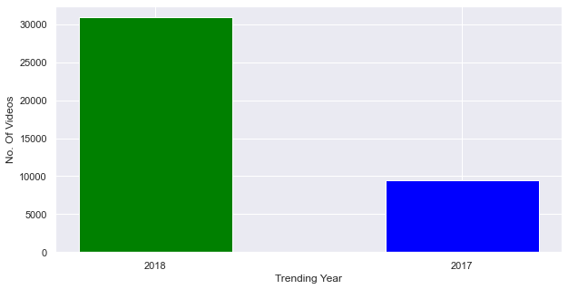

```python
day=df['trending_date'].dt.strftime ('%Y')
my_dict=(day.value_counts()).to_dict()
count= pd.DataFrame(list(my_dict.items()),columns = ['Trending year','No. Of Videos'])
fig=plt.figure(figsize=(10,5))
plt.bar(count['Trending year'],count['No. Of Videos'],color=['green', 'blue'],width=0.5)
plt.xlabel("Trending Year")
plt.ylabel("No. Of Videos")
plt.show()
```

Vengono visualizzati anche i video per ogni mese. Si nota un maggiore ingresso di video in tendenza nei mesi di marzo, dicembre e maggio

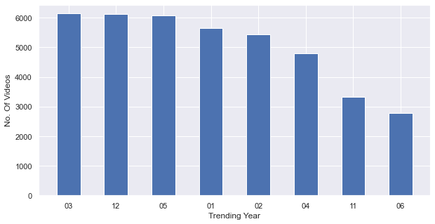

```python
day=df['trending_date'].dt.strftime ('%m')
my_dict=(day.value_counts()).to_dict()
count= pd.DataFrame(list(my_dict.items()),columns = ['Trending month','No. Of Videos'])
fig=plt.figure(figsize=(10,5))
plt.bar(count['Trending month'],count['No. Of Videos'],width=0.5)
plt.xlabel("Trending Year")
plt.ylabel("No. Of Videos")
plt.show()
```

Vengono visualizzati anche i giorni del mese in cui i video entrano in tendenza.

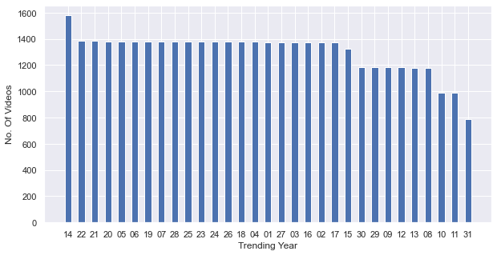

```python
day=df['trending_date'].dt.strftime ('%d')
my_dict=(day.value_counts()).to_dict()
count= pd.DataFrame(list(my_dict.items()),columns = ['Trending day','No. Of Videos'])
fig=plt.figure(figsize=(10,5))
plt.bar(count['Trending day'],count['No. Of Videos'],width=0.5)
plt.xlabel("Trending Year")
plt.ylabel("No. Of Videos")
plt.show()
```

Si decide così di creare tre colonne rispettivamente per anni mesi e giorni, successivamente viene assegnato 0 ai video che presentano 2017 ed 1 a quelli che presentano 2018 nella colonna "year".

```python
df['year'] = df['trending_date'].dt.strftime('%Y')
df['month'] = df['trending_date'].dt.strftime('%m')
df['day'] = df['trending_date'].dt.strftime('%d')
```

```python
year_dict = {'2017': 0,'2018':1}
df['year'] = df['year'].map(year_dict)
```

Si decide di droppare la colonna trending_date in quanto sono già state estratte le informazioni necessarie.

```python
df.drop(['trending_date'],axis=1, inplace=True)
```

```python
df.head()
```

|  | video_id | title | channel_title | category_id | publish_time | tags | views | likes | dislikes | comment_count | thumbnail_link | comments_disabled | ratings_disabled | video_error_or_removed | description | year | month | day |
| --- | --- | --- | --- | --- | --- | --- | --- | --- | --- | --- | --- | --- | --- | --- | --- | --- | --- | --- |
| 0 | 2kyS6SvSYSE | WE WANT TO TALK ABOUT OUR MARRIAGE | CaseyNeistat | 22 | 2017-11-13 17:13:01 | SHANtell martin | 748374 | 57527 | 2966 | 15954 | https://i.ytimg.com/vi/2kyS6SvSYSE/default.jpg | False | False | False | SHANTELL'S CHANNEL - https://www.youtube.com/s... | 0 | 11 | 14 |
| 1 | 1ZAPwfrtAFY | The Trump Presidency: Last Week Tonight with J... | LastWeekTonight | 24 | 2017-11-13 07:30:00 | last week tonight trump presidency\|"last week ... | 2418783 | 97185 | 6146 | 12703 | https://i.ytimg.com/vi/1ZAPwfrtAFY/default.jpg | False | False | False | One year after the presidential election, John... | 0 | 11 | 14 |
| 2 | 5qpjK5DgCt4 | Racist Superman \| Rudy Mancuso, King Bach & Le... | Rudy Mancuso | 23 | 2017-11-12 19:05:24 | racist superman\|"rudy"\|"mancuso"\|"king"\|"bach"... | 3191434 | 146033 | 5339 | 8181 | https://i.ytimg.com/vi/5qpjK5DgCt4/default.jpg | False | False | False | WATCH MY PREVIOUS VIDEO ▶ \n\nSUBSCRIBE ► http... | 0 | 11 | 14 |
| 3 | puqaWrEC7tY | Nickelback Lyrics: Real or Fake? | Good Mythical Morning | 24 | 2017-11-13 11:00:04 | rhett and link\|"gmm"\|"good mythical morning"\|"... | 343168 | 10172 | 666 | 2146 | https://i.ytimg.com/vi/puqaWrEC7tY/default.jpg | False | False | False | Today we find out if Link is a Nickelback amat... | 0 | 11 | 14 |
| 4 | d380meD0W0M | I Dare You: GOING BALD!? | nigahiga | 24 | 2017-11-12 18:01:41 | ryan\|"higa"\|"higatv"\|"nigahiga"\|"i dare you"\|"... | 2095731 | 132235 | 1989 | 17518 | https://i.ytimg.com/vi/d380meD0W0M/default.jpg | False | False | False | I know it's been a while since we did this sho... | 0 | 11 | 14 |

```python
df.dtypes
```

```
video_id                          object
title                             object
channel_title                     object
category_id                        int64
publish_time              datetime64[ns]
tags                              object
views                              int64
likes                              int64
dislikes                           int64
comment_count                      int64
thumbnail_link                    object
comments_disabled                   bool
ratings_disabled                    bool
video_error_or_removed              bool
description                       object
year                               int64
month                             object
day                               object
dtype: object
```

```python
df.reset_index(drop=True, inplace=True)
```

## Words processing

L'analisi delle parole utilizzate è un problema fondamentale da analizzare ai fini della categorizzazione dei video, il quale può ovviamente contenerne diverse.

```python
len(df['title'].unique())
```

```
6357
```

Si procede con un'analisi delle parole presenti nei titoli, in particolare viene creata una lista contenente tutte le parole presenti nei singoli titoli. Si sceglie di procedere in questo modo in quanto si può procedere con una migliore analisi rispetto che ad utilizzare alcuni strumenti di encoding (es. LableEncoder).

```python
all_words = []
for x in range(df.shape[0]) :
    all_words = all_words  +  df['title'][x].split()
```

```python
len(all_words)
```

```
344296
```

Successivamente la lista viene convertita in una series così da poter contare quante volte le singole parole sono ripetute.

```python
all_words_series = pd.Series(all_words)
```

si sceglie di effettuare una selezione delle parole considerate "top", ovvero quelle presenti con una maggiore frequenza. In questo caso vengono selezionate le prime 30.

```python
top_words =  all_words_series.value_counts()[:30]
top_words
```

```
-            11384
|            10546
The           5658
the           3557
a             2519
of            2315
to            2300
in            2136
A             2114
&             2009
I             1933
Video)        1889
and           1882
Trailer       1867
How           1653
with          1638
2018          1599
(Official     1581
Official      1553
on            1533
To            1377
You           1240
My            1072
ft.           1016
for           1007
In             936
With           881
Is             821
at             804
What           768
dtype: int64
```

```python
top_words = list(top_words.index)
```

```python
top_words
```

```
['-',
 '|',
 'The',
 'the',
 'a',
 'of',
 'to',
 'in',
 'A',
 '&',
 'I',
 'Video)',
 'and',
 'Trailer',
 'How',
 'with',
 '2018',
 '(Official',
 'Official',
 'on',
 'To',
 'You',
 'My',
 'ft.',
 'for',
 'In',
 'With',
 'Is',
 'at',
 'What']
```

Si procede a rimuovere da queste le parole/simboli che da sole sono prive di significato.

```python
top_words.remove('-')
top_words.remove('|')
top_words.remove('The')
top_words.remove('&')
top_words.remove('the')
top_words.remove('of')
top_words.remove('and')
top_words.remove('in')
top_words.remove('on')
top_words.remove('a')
top_words.remove('with')
top_words.remove('In')
top_words.remove('To')
top_words.remove('A')
top_words.remove('for')
```

```python
top_words
```

```
['to',
 'I',
 'Video)',
 'Trailer',
 'How',
 '2018',
 '(Official',
 'Official',
 'You',
 'My',
 'ft.',
 'With',
 'Is',
 'at',
 'What']
```

In questa fase si decide di creare una lista per ogni parola e andare a verificare se è presente o meno all'interno del titolo, nel caso in cui la parola è presente si aggiunge un 1, altrimenti 0.

```python
l1 = []
l2 = []
l3 = []
l4 = []
l5 = []
l6 = []
l7 = []
l8 = []
l9 = []
l10 = []
l11 = []
l12 = []
l13 = []
l14 = []

this_list = []
for x in range(df.shape[0]) :
    this_list  =  df['title'][x].split()

    if ('Video)' in this_list):
        l1.append(1)
    else :
        l1.append(0)

    if ('(Official' in this_list) or ( 'Official'in this_list):
        l2.append(1)
    else :
        l2.append(0)

    if 'Trailer' in this_list :
        l3.append(1)
    else :
        l3.append(0)

    if 'You' in this_list :
        l4.append(1)
    else :
        l4.append(0)
    if 'With' in this_list :
        l5.append(1)
    else :
        l5.append(0)
    if 'What' in this_list :
        l6.append(1)
    else :
        l6.append(0)
    if 'My' in this_list :
        l7.append(1)
    else :
        l7.append(0)
    if 'at' in this_list :
        l8.append(1)
    else :
        l8.append(0)
    if  'I'  in this_list :
        l9.append(1)
    else :
        l9.append(0)
    if 'to' in this_list :
        l10.append(1)
    else :
        l10.append(0)
    if '2018' in this_list :
        l11.append(1)
    else :
        l11.append(0)
    if 'Is' in this_list :
        l12.append(1)
    else :
        l12.append(0)

    if 'ft.' in this_list :
        l13.append(1)
    else :
        l13.append(0)

    if 'How' in this_list :
        l14.append(1)
    else :
        l14.append(0)
```

```python
len(l12)
```

```
40332
```

Una volta preparate le parole, si procede con l'inserimento di esse all'interno del dataset. In particolare viene creata una colonna per ogni parola dove con 1 si intende che la parola è presente all'interno del titolo, mentre con 0 si indica la sua assenza.

```python
df['word1'] = l1
df['word2'] = l2
df['word3'] = l3
df['word4'] = l4
df['word5'] = l5
df['word6'] = l6
df['word7'] = l7
df['word8'] = l8
df['word9'] = l9
df['word10'] = l10
df['word11'] = l11
df['word12'] = l12
df['word13'] = l13
df['word14'] = l14
```

Si decise quindi di droppare l'attributo "title" dopo averne estratto le informazioni necessarie.

```python
df.drop(['title'], axis = 1, inplace = True)
```

```python
df.head()
```

|  | video_id | channel_title | category_id | publish_time | tags | views | likes | dislikes | comment_count | thumbnail_link | ... | word5 | word6 | word7 | word8 | word9 | word10 | word11 | word12 | word13 | word14 |
| --- | --- | --- | --- | --- | --- | --- | --- | --- | --- | --- | --- | --- | --- | --- | --- | --- | --- | --- | --- | --- | --- |
| 0 | 2kyS6SvSYSE | CaseyNeistat | 22 | 2017-11-13 17:13:01 | SHANtell martin | 748374 | 57527 | 2966 | 15954 | https://i.ytimg.com/vi/2kyS6SvSYSE/default.jpg | ... | 0 | 0 | 0 | 0 | 0 | 0 | 0 | 0 | 0 | 0 |
| 1 | 1ZAPwfrtAFY | LastWeekTonight | 24 | 2017-11-13 07:30:00 | last week tonight trump presidency\|"last week ... | 2418783 | 97185 | 6146 | 12703 | https://i.ytimg.com/vi/1ZAPwfrtAFY/default.jpg | ... | 0 | 0 | 0 | 0 | 0 | 0 | 0 | 0 | 0 | 0 |
| 2 | 5qpjK5DgCt4 | Rudy Mancuso | 23 | 2017-11-12 19:05:24 | racist superman\|"rudy"\|"mancuso"\|"king"\|"bach"... | 3191434 | 146033 | 5339 | 8181 | https://i.ytimg.com/vi/5qpjK5DgCt4/default.jpg | ... | 0 | 0 | 0 | 0 | 0 | 0 | 0 | 0 | 0 | 0 |
| 3 | puqaWrEC7tY | Good Mythical Morning | 24 | 2017-11-13 11:00:04 | rhett and link\|"gmm"\|"good mythical morning"\|"... | 343168 | 10172 | 666 | 2146 | https://i.ytimg.com/vi/puqaWrEC7tY/default.jpg | ... | 0 | 0 | 0 | 0 | 0 | 0 | 0 | 0 | 0 | 0 |
| 4 | d380meD0W0M | nigahiga | 24 | 2017-11-12 18:01:41 | ryan\|"higa"\|"higatv"\|"nigahiga"\|"i dare you"\|"... | 2095731 | 132235 | 1989 | 17518 | https://i.ytimg.com/vi/d380meD0W0M/default.jpg | ... | 0 | 0 | 0 | 0 | 1 | 0 | 0 | 0 | 0 | 0 |

5 rows × 31 columns

Ora si vuole spostare l'attenzione sull'attributo target ovvero le categorie, si nota che sono presenti ben 16 categorie distinte all'interno del dataset.

```python
df['category_id'].unique()
```

```
array([22, 24, 23, 28,  1, 25, 17, 10, 15, 27, 26,  2, 19, 20, 29, 43],
      dtype=int64)
```

```python
len(df['category_id'].unique())
```

```
16
```

Ai fini di una maggiore comprensione delle categorie si utilizza un mapping trovato su kaggle. Dunque si aggiunge un attributo "category_name" nel dataset.

```python
df['category_name'] = np.nan
df.loc[(df["category_id"] == 1),"category_name"] = 'Film and Animation'
df.loc[(df["category_id"] == 2),"category_name"] = 'Cars and Vehicles'
df.loc[(df["category_id"] == 10),"category_name"] = 'Music'
df.loc[(df["category_id"] == 15),"category_name"] = 'Pets and Animals'
df.loc[(df["category_id"] == 17),"category_name"] = 'Sport'
df.loc[(df["category_id"] == 19),"category_name"] = 'Travel and Events'
df.loc[(df["category_id"] == 20),"category_name"] = 'Gaming'
df.loc[(df["category_id"] == 22),"category_name"] = 'People and Blogs'
df.loc[(df["category_id"] == 23),"category_name"] = 'Comedy'
df.loc[(df["category_id"] == 24),"category_name"] = 'Entertainment'
df.loc[(df["category_id"] == 25),"category_name"] = 'News and Politics'
df.loc[(df["category_id"] == 26),"category_name"] = 'How to and Style'
df.loc[(df["category_id"] == 27),"category_name"] = 'Education'
df.loc[(df["category_id"] == 28),"category_name"] = 'Science and Technology'
df.loc[(df["category_id"] == 29),"category_name"] = 'Non Profits and Activism'
df.loc[(df["category_id"] == 43),"category_name"] = 'Shows'
```

Dal grafico si nota che "Entertainment" è la categoria con il maggior numero di video.

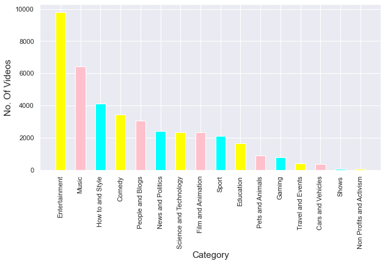

```python
my_dict=(df['category_name'].value_counts()).to_dict()
count= pd.DataFrame(list(my_dict.items()),columns = ['Category','No. Of Videos'])
fig=plt.figure(figsize=(10,5))
plt.bar(count['Category'],count['No. Of Videos'],color=['yellow', 'pink', 'cyan'],width=0.5)
plt.xticks(rotation=90)
plt.xlabel("Category",size=15)
plt.ylabel("No. Of Videos",size=15)
plt.show()
```

Viene effettuata anche un'analisi sugli orari di pubblicazione dei video, dalla quale emerge che la maggior parte di essi viene pubblicata nell'intervallo 15:00-17:00.

```python
len(df['publish_time'].unique())
```

```
6172
```

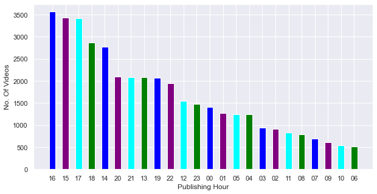

```
16    3561
15    3427
17    3422
18    2859
14    2770
20    2101
21    2085
13    2083
19    2066
22    1946
12    1547
23    1478
00    1407
01    1270
05    1247
04    1246
03     939
02     906
11     834
08     790
07     698
09     604
10     538
06     508
Name: publish_time, dtype: int64
```

```python
hour=df.publish_time.apply(lambda x: x.strftime("%H"))
my_dict=(hour.value_counts()).to_dict()
count= pd.DataFrame(list(my_dict.items()),columns = ['Publishing Hour','No. Of Videos'])
fig=plt.figure(figsize=(10,5))
plt.bar(count['Publishing Hour'],count['No. Of Videos'],color=['blue', 'purple', 'cyan', 'green'],width=0.5)
plt.xlabel("Publishing Hour")
plt.ylabel("No. Of Videos")
plt.show()
print(hour.value_counts())
```

Si decide dunque di dividere gli orari di pubblicazione in 4 intervalli, il primo compreso tra mezzanotte e le 5 di mattina, il secondo compreso tra le 6 di mattina e le 11, il terzo compreso tra le 12 e le 17, e le restanti verranno inserite nel quarto intervallo.

```python
publish_quarter = []

for x in range(df.shape[0]):
    publish_hour = int(str(df['publish_time'][x])[11:13])
    if publish_hour >=0 and publish_hour < 6  :
        publish_quarter.append(1)
    elif publish_hour >=6 and publish_hour < 12  :
        publish_quarter.append(2)
    elif publish_hour >=12 and publish_hour < 18  :
        publish_quarter.append(3)
    else:
        publish_quarter.append(4)
```

```python
df['publish_quarter'] = publish_quarter
```

```python
df.head()
```

|  | video_id | channel_title | category_id | publish_time | tags | views | likes | dislikes | comment_count | thumbnail_link | ... | word7 | word8 | word9 | word10 | word11 | word12 | word13 | word14 | category_name | publish_quarter |
| --- | --- | --- | --- | --- | --- | --- | --- | --- | --- | --- | --- | --- | --- | --- | --- | --- | --- | --- | --- | --- | --- |
| 0 | 2kyS6SvSYSE | CaseyNeistat | 22 | 2017-11-13 17:13:01 | SHANtell martin | 748374 | 57527 | 2966 | 15954 | https://i.ytimg.com/vi/2kyS6SvSYSE/default.jpg | ... | 0 | 0 | 0 | 0 | 0 | 0 | 0 | 0 | People and Blogs | 3 |
| 1 | 1ZAPwfrtAFY | LastWeekTonight | 24 | 2017-11-13 07:30:00 | last week tonight trump presidency\|"last week ... | 2418783 | 97185 | 6146 | 12703 | https://i.ytimg.com/vi/1ZAPwfrtAFY/default.jpg | ... | 0 | 0 | 0 | 0 | 0 | 0 | 0 | 0 | Entertainment | 2 |
| 2 | 5qpjK5DgCt4 | Rudy Mancuso | 23 | 2017-11-12 19:05:24 | racist superman\|"rudy"\|"mancuso"\|"king"\|"bach"... | 3191434 | 146033 | 5339 | 8181 | https://i.ytimg.com/vi/5qpjK5DgCt4/default.jpg | ... | 0 | 0 | 0 | 0 | 0 | 0 | 0 | 0 | Comedy | 4 |
| 3 | puqaWrEC7tY | Good Mythical Morning | 24 | 2017-11-13 11:00:04 | rhett and link\|"gmm"\|"good mythical morning"\|"... | 343168 | 10172 | 666 | 2146 | https://i.ytimg.com/vi/puqaWrEC7tY/default.jpg | ... | 0 | 0 | 0 | 0 | 0 | 0 | 0 | 0 | Entertainment | 2 |
| 4 | d380meD0W0M | nigahiga | 24 | 2017-11-12 18:01:41 | ryan\|"higa"\|"higatv"\|"nigahiga"\|"i dare you"\|"... | 2095731 | 132235 | 1989 | 17518 | https://i.ytimg.com/vi/d380meD0W0M/default.jpg | ... | 0 | 0 | 1 | 0 | 0 | 0 | 0 | 0 | Entertainment | 4 |

5 rows × 33 columns

Si procede con l'analisi dei tag considerati importanti ai fini della classificazione dei video per categorie.

```python
len(df['tags'].unique())
```

```
6008
```

Viene mostrato l'attributo "tags".

```python
df['tags'][:10]
```

```
0                                      SHANtell martin
1    last week tonight trump presidency|"last week ...
2    racist superman|"rudy"|"mancuso"|"king"|"bach"...
3    rhett and link|"gmm"|"good mythical morning"|"...
4    ryan|"higa"|"higatv"|"nigahiga"|"i dare you"|"...
5    ijustine|"week with iPhone X"|"iphone x"|"appl...
6    SNL|"Saturday Night Live"|"SNL Season 43"|"Epi...
7    5 Ice Cream Gadgets|"Ice Cream"|"Cream Sandwic...
8    Trailer|"Hugh Jackman"|"Michelle Williams"|"Za...
9    vox.com|"vox"|"explain"|"shift change"|"future...
Name: tags, dtype: object
```

Dopo la visualizzazione dell'attributo "tags" si decide di procedere con la codifica di alcuni attributi del dataset sfruttando un LabelEncoder.

```python
from sklearn.preprocessing import LabelEncoder
le = LabelEncoder()
for i in df.columns:
    if i in ['channel_title','publish_time','tags','comments_disabled','ratings_disabled','video_error_or_removed']:
        df[i] = le.fit_transform(df[i])
df.head()
```

|  | video_id | channel_title | category_id | publish_time | tags | views | likes | dislikes | comment_count | thumbnail_link | ... | word7 | word8 | word9 | word10 | word11 | word12 | word13 | word14 | category_name | publish_quarter |
| --- | --- | --- | --- | --- | --- | --- | --- | --- | --- | --- | --- | --- | --- | --- | --- | --- | --- | --- | --- | --- | --- |
| 0 | 2kyS6SvSYSE | 322 | 22 | 302 | 1888 | 748374 | 57527 | 2966 | 15954 | https://i.ytimg.com/vi/2kyS6SvSYSE/default.jpg | ... | 0 | 0 | 0 | 0 | 0 | 0 | 0 | 0 | People and Blogs | 3 |
| 1 | 1ZAPwfrtAFY | 979 | 24 | 272 | 4298 | 2418783 | 97185 | 6146 | 12703 | https://i.ytimg.com/vi/1ZAPwfrtAFY/default.jpg | ... | 0 | 0 | 0 | 0 | 0 | 0 | 0 | 0 | Entertainment | 2 |
| 2 | 5qpjK5DgCt4 | 1455 | 23 | 256 | 5003 | 3191434 | 146033 | 5339 | 8181 | https://i.ytimg.com/vi/5qpjK5DgCt4/default.jpg | ... | 0 | 0 | 0 | 0 | 0 | 0 | 0 | 0 | Comedy | 4 |
| 3 | puqaWrEC7tY | 688 | 24 | 276 | 5099 | 343168 | 10172 | 666 | 2146 | https://i.ytimg.com/vi/puqaWrEC7tY/default.jpg | ... | 0 | 0 | 0 | 0 | 0 | 0 | 0 | 0 | Entertainment | 2 |
| 4 | d380meD0W0M | 2086 | 24 | 254 | 5166 | 2095731 | 132235 | 1989 | 17518 | https://i.ytimg.com/vi/d380meD0W0M/default.jpg | ... | 0 | 0 | 1 | 0 | 0 | 0 | 0 | 0 | Entertainment | 4 |

5 rows × 33 columns

Ora rimane da considerare alcuni attributi come: "views", "likes", "dislikes" e "comment_count". Questi attributi presentano un range di valori molto elevato, per questo motivo si decide di dividerli in intervalli.

```python
len(df['views'].unique())
```

```
39927
```

```python
df['views'].min()
```

```
549
```

```python
df['views'].max()
```

```
225211923
```

L'attributo "views" presenta un minimo di 549 ed un massimo di 225 milioni circa, come c'era da aspettarsi l'intervallo è molto grande.

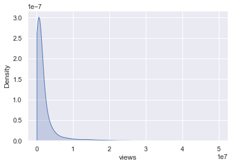

```python
sns.kdeplot(df['views'], shade = True,clip=(0.0, 50000000.0))
```

Viene definita una funzione "feature_sectors" così da generare 10 settori che dipendono dal massimo valore che si passa in input, così da avere un maggiore "controllo" sugli attributi che seguiranno.

```python
def feature_sectors(data , maxx , feature , new_featre):
    step = (maxx- data[feature].min())/10
    new_list = []
    minn = data[feature].min()
    for x in range(data.shape[0]) :
        if data[feature][x] <= (minn + step):
            new_list.append(1)
        elif data[feature][x] <= (minn + (2*step)):
            new_list.append(2)
        elif data[feature][x] <= (minn + (3*step)):
            new_list.append(3)
        elif data[feature][x] <= (minn + (4*step)):
            new_list.append(4)
        elif data[feature][x] <= (minn + (5*step)):
            new_list.append(5)
        elif data[feature][x] <= (minn + (6*step)):
            new_list.append(6)
        elif data[feature][x] <= (minn + (7*step)):
            new_list.append(7)
        elif data[feature][x] <= (minn + (8*step)):
            new_list.append(8)
        elif data[feature][x] <= (minn + (9*step)):
            new_list.append(9)
        else:
            new_list.append(10)
    data.insert(data.shape[1], new_featre , new_list)
```

In primo luogo si pone maxx = 50 milioni.

```python
feature_sectors(df ,50000000 , 'views' , 'views sector')
```

```python
df.head()
```

|  | video_id | channel_title | category_id | publish_time | tags | views | likes | dislikes | comment_count | thumbnail_link | ... | word8 | word9 | word10 | word11 | word12 | word13 | word14 | category_name | publish_quarter | views sector |
| --- | --- | --- | --- | --- | --- | --- | --- | --- | --- | --- | --- | --- | --- | --- | --- | --- | --- | --- | --- | --- | --- |
| 0 | 2kyS6SvSYSE | 322 | 22 | 302 | 1888 | 748374 | 57527 | 2966 | 15954 | https://i.ytimg.com/vi/2kyS6SvSYSE/default.jpg | ... | 0 | 0 | 0 | 0 | 0 | 0 | 0 | People and Blogs | 3 | 1 |
| 1 | 1ZAPwfrtAFY | 979 | 24 | 272 | 4298 | 2418783 | 97185 | 6146 | 12703 | https://i.ytimg.com/vi/1ZAPwfrtAFY/default.jpg | ... | 0 | 0 | 0 | 0 | 0 | 0 | 0 | Entertainment | 2 | 1 |
| 2 | 5qpjK5DgCt4 | 1455 | 23 | 256 | 5003 | 3191434 | 146033 | 5339 | 8181 | https://i.ytimg.com/vi/5qpjK5DgCt4/default.jpg | ... | 0 | 0 | 0 | 0 | 0 | 0 | 0 | Comedy | 4 | 1 |
| 3 | puqaWrEC7tY | 688 | 24 | 276 | 5099 | 343168 | 10172 | 666 | 2146 | https://i.ytimg.com/vi/puqaWrEC7tY/default.jpg | ... | 0 | 0 | 0 | 0 | 0 | 0 | 0 | Entertainment | 2 | 1 |
| 4 | d380meD0W0M | 2086 | 24 | 254 | 5166 | 2095731 | 132235 | 1989 | 17518 | https://i.ytimg.com/vi/d380meD0W0M/default.jpg | ... | 0 | 1 | 0 | 0 | 0 | 0 | 0 | Entertainment | 4 | 1 |

5 rows × 34 columns

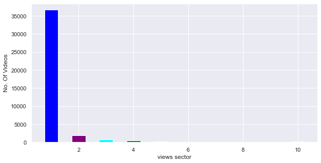

```python
my_dict=(df['views sector'].value_counts()).to_dict()
count= pd.DataFrame(list(my_dict.items()),columns = ['views sector','No. Of Videos'])
fig=plt.figure(figsize=(10,5))
plt.bar(count['views sector'],count['No. Of Videos'],color=['blue', 'purple', 'cyan', 'green'],width=0.5)
plt.xlabel("views sector")
plt.ylabel("No. Of Videos")
plt.show()
```

Dal grafico risula ancora essere molto sbilanciato, ci sono molti settori che non sono coperti da alcun valore.

Si limita ancor di più l'intervallo portando maxx = 1 milione.

```python
df.drop(['views sector'],axis=1, inplace=True)
```

```python
feature_sectors(df ,1000000 , 'views' , 'views sector')
```

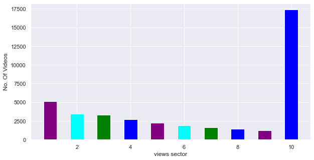

```python
my_dict=(df['views sector'].value_counts()).to_dict()
count= pd.DataFrame(list(my_dict.items()),columns = ['views sector','No. Of Videos'])
fig=plt.figure(figsize=(10,5))
plt.bar(count['views sector'],count['No. Of Videos'],color=['blue', 'purple', 'cyan', 'green'],width=0.5)
plt.xlabel("views sector")
plt.ylabel("No. Of Videos")
plt.show()
```

Il grafico adesso risulta essere troppo sbilanciato per via del piccolo intervallo scelto, dato che la maggior parte dei video viene messa nel decimo intervallo.

Si procede quindi con un aumento del valore maxx, portandolo a 10 milioni.

```python
df.drop(['views sector'],axis=1, inplace=True)
```

```python
feature_sectors(df ,10000000 , 'views' , 'views sector')
```

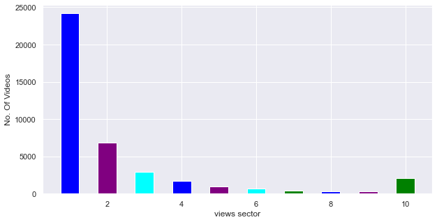

```python
my_dict=(df['views sector'].value_counts()).to_dict()
count= pd.DataFrame(list(my_dict.items()),columns = ['views sector','No. Of Videos'])
fig=plt.figure(figsize=(10,5))
plt.bar(count['views sector'],count['No. Of Videos'],color=['blue', 'purple', 'cyan', 'green'],width=0.5)
plt.xlabel("views sector")
plt.ylabel("No. Of Videos")
plt.show()
```

In questo caso abbiamo una distribuzione migliore. Nel primo intervallo sono presenti la maggior parte dei video, che hanno da un milione di viws a scendere.

Si procede con l'analisi dell'attributo "likes".

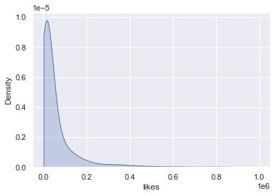

```python
sns.kdeplot(df['likes'], shade = True,clip=(0.0, 1000000.0))
```

Come maxx in questo caso viene scelto 500 mila, la maggior parte dei video si aggira intorno alla prima sezione, dunque intorno ai 50 mila mi piace.

```python
feature_sectors(df ,500000 , 'likes' , 'likes sectors')
```

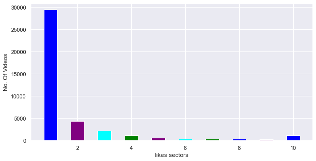

```python
my_dict=(df['likes sectors'].value_counts()).to_dict()
count= pd.DataFrame(list(my_dict.items()),columns = ['likes sectors','No. Of Videos'])
fig=plt.figure(figsize=(10,5))
plt.bar(count['likes sectors'],count['No. Of Videos'],color=['blue', 'purple', 'cyan', 'green'],width=0.5)
plt.xlabel("likes sectors")
plt.ylabel("No. Of Videos")
plt.show()
```

I valori dell'attributo "dislikes" sono sicuramente minori rispetto a quelli dei due trattati in precedenza come si può notare dalla sua distribuzione.

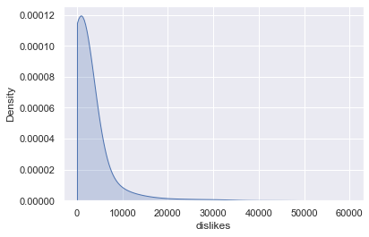

```python
 sns.kdeplot(df['dislikes'], shade=True,clip=(0.0, 60000.0))
```

Si decide quindi di dividere gli intervalli in base al valore 50 mila.

```python
feature_sectors(df ,50000 , 'dislikes' , 'dislikes sectors')
```

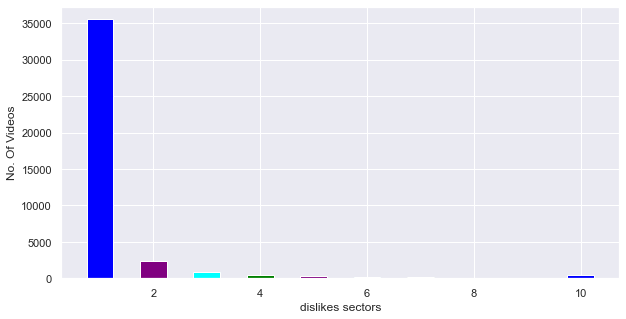

```python
my_dict=(df['dislikes sectors'].value_counts()).to_dict()
count= pd.DataFrame(list(my_dict.items()),columns = ['dislikes sectors','No. Of Videos'])
fig=plt.figure(figsize=(10,5))
plt.bar(count['dislikes sectors'],count['No. Of Videos'],color=['blue', 'purple', 'cyan', 'green'],width=0.5)
plt.xlabel("dislikes sectors")
plt.ylabel("No. Of Videos")
plt.show()
```

Anche in questo caso il valore scelto per la divisione in intervalli è troppo grande, per cui si decide di diminuirlo e considerare un valore pari a 10000.

```python
df.drop(['dislikes sectors'],axis=1, inplace=True)
```

```python
feature_sectors(df ,10000 , 'dislikes' , 'dislikes sectors')
```

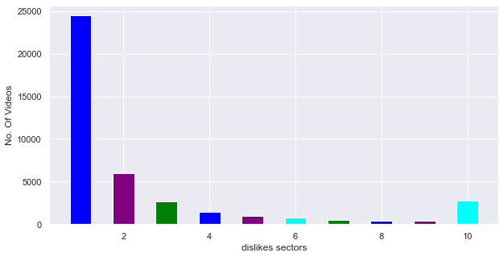

```python
my_dict=(df['dislikes sectors'].value_counts()).to_dict()
count= pd.DataFrame(list(my_dict.items()),columns = ['dislikes sectors','No. Of Videos'])
fig=plt.figure(figsize=(10,5))
plt.bar(count['dislikes sectors'],count['No. Of Videos'],color=['blue', 'purple', 'cyan', 'green'],width=0.5)
plt.xlabel("dislikes sectors")
plt.ylabel("No. Of Videos")
plt.show()
```

Si procede con la gestione dell'ultimo attributo: "comment_count".

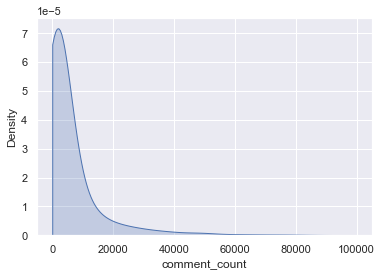

```python
sns.kdeplot(df['comment_count'], shade = True,clip=(0.0, 100000.0))
```

```python
feature_sectors(df ,10000 , 'comment_count' , 'comment_count sectors')
```

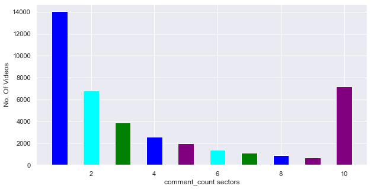

```python
my_dict=(df['comment_count sectors'].value_counts()).to_dict()
count= pd.DataFrame(list(my_dict.items()),columns = ['comment_count sectors','No. Of Videos'])
fig=plt.figure(figsize=(10,5))
plt.bar(count['comment_count sectors'],count['No. Of Videos'],color=['blue', 'purple', 'cyan', 'green'],width=0.5)
plt.xlabel("comment_count sectors")
plt.ylabel("No. Of Videos")
plt.show()
```

Ora il dataset contiene 4 nuove colonne: views sector', 'likes sectors', 'dislikes sectors', 'comment_count sectors' le quali hanno dei valori interi da 1 a 10 che rappresentano gli intervalli in che si è deciso di utilizzare.

```python
df.columns
```

```
Index(['video_id', 'channel_title', 'category_id', 'publish_time', 'tags',
       'views', 'likes', 'dislikes', 'comment_count', 'thumbnail_link',
       'comments_disabled', 'ratings_disabled', 'video_error_or_removed',
       'description', 'year', 'month', 'day', 'word1', 'word2', 'word3',
       'word4', 'word5', 'word6', 'word7', 'word8', 'word9', 'word10',
       'word11', 'word12', 'word13', 'word14', 'category_name',
       'publish_quarter', 'views sector', 'likes sectors', 'dislikes sectors',
       'comment_count sectors'],
      dtype='object')
```

Vengono droppate alcune colonne ormai non più utili.

```python
df.drop(['thumbnail_link','video_id','category_name'],axis=1, inplace=True)
```

```python
df.head()
```

|  | channel_title | category_id | publish_time | tags | views | likes | dislikes | comment_count | comments_disabled | ratings_disabled | ... | word10 | word11 | word12 | word13 | word14 | publish_quarter | views sector | likes sectors | dislikes sectors | comment_count sectors |
| --- | --- | --- | --- | --- | --- | --- | --- | --- | --- | --- | --- | --- | --- | --- | --- | --- | --- | --- | --- | --- | --- |
| 0 | 322 | 22 | 302 | 1888 | 748374 | 57527 | 2966 | 15954 | 0 | 0 | ... | 0 | 0 | 0 | 0 | 0 | 3 | 1 | 2 | 3 | 10 |
| 1 | 979 | 24 | 272 | 4298 | 2418783 | 97185 | 6146 | 12703 | 0 | 0 | ... | 0 | 0 | 0 | 0 | 0 | 2 | 3 | 2 | 7 | 10 |
| 2 | 1455 | 23 | 256 | 5003 | 3191434 | 146033 | 5339 | 8181 | 0 | 0 | ... | 0 | 0 | 0 | 0 | 0 | 4 | 4 | 3 | 6 | 9 |
| 3 | 688 | 24 | 276 | 5099 | 343168 | 10172 | 666 | 2146 | 0 | 0 | ... | 0 | 0 | 0 | 0 | 0 | 2 | 1 | 1 | 1 | 3 |
| 4 | 2086 | 24 | 254 | 5166 | 2095731 | 132235 | 1989 | 17518 | 0 | 0 | ... | 0 | 0 | 0 | 0 | 0 | 4 | 3 | 3 | 2 | 10 |

5 rows × 34 columns

L'attributo description non viene considerato in questo caso in quanto sarebbe troppo complicato ed uno spreco di risorse cercare di utilizzare un encoder in quanto presenta troppi valori unici e diversi caratteri, pertanto viene droppato.

```python
len(df['description'].unique())
```

```
6901
```

```python
df.drop(['description'],axis=1, inplace=True)
```

```python
df.info()
```

```
<class 'pandas.core.frame.DataFrame'>
RangeIndex: 40332 entries, 0 to 40331
Data columns (total 33 columns):
 #   Column                  Non-Null Count  Dtype
---  ------                  --------------  -----
 0   channel_title           40332 non-null  int32
 1   category_id             40332 non-null  int64
 2   publish_time            40332 non-null  int64
 3   tags                    40332 non-null  int32
 4   views                   40332 non-null  int64
 5   likes                   40332 non-null  int64
 6   dislikes                40332 non-null  int64
 7   comment_count           40332 non-null  int64
 8   comments_disabled       40332 non-null  int64
 9   ratings_disabled        40332 non-null  int64
```

[output cut: 25 more lines]

Viene quindi mostrata la matrice di correlazione.

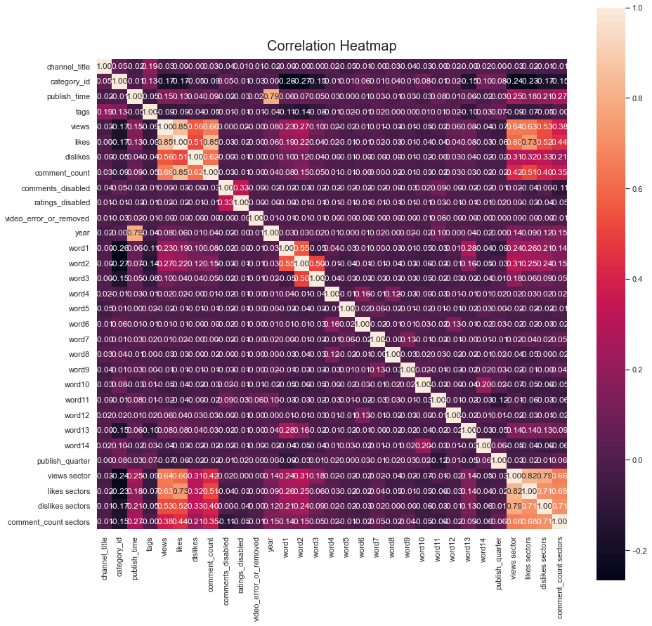

```python
corr = df.corr()
plt.figure(figsize=(15, 15))
heatmap = sns.heatmap(corr, annot=True, square = True, fmt='.2f')
heatmap.set_title('Correlation Heatmap', fontdict={'fontsize':20}, pad=12);
plt.show()
```

Ci si concentra sull'attributo target category_id.

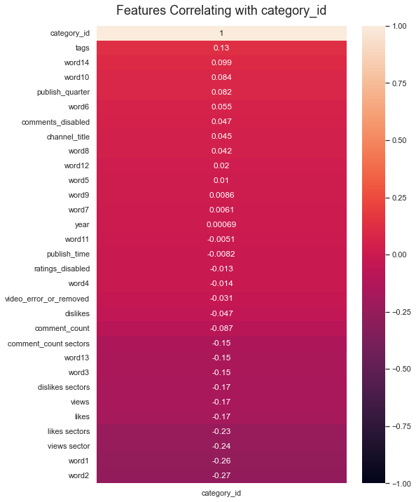

```python
corr[['category_id']].sort_values(by='category_id', ascending = False)
plt.figure(figsize=(8, 12))
heatmap = sns.heatmap(corr[['category_id']].sort_values(by='category_id', ascending=False), vmin=-1, vmax=1, annot=True)
heatmap.set_title('Features Correlating with category_id', fontdict={'fontsize':18}, pad=16);
```

Vengono inoltre droppate le colonne relative a 'views','likes','comment_count','dislikes' e si decide quindi di tenere quelle relative alla divisione in settori.

```python
df.drop(['views','likes','comment_count','dislikes'], axis = 1, inplace = True)
```

# Training dei Classificatori

Le metriche per la valutazione delle performance dei classificatori che si utilizzano in questo caso sono:

- accuracy: rappresenta il grado di vicinanza al valore reale ed è definita come il rapporto tra il numero di previsioni corrette ed il numero totale di previsioni.
- recall: misura quanto il modello identifica correttamente i valori positivi.
- precision: è il rapporto tra i veri positivi e tutti i positivi (True Positive + False Positive).

Si utilizza la funzione compute_performance per il calcolo di queste metriche per ogni modello.

```python
from sklearn.model_selection import *
from sklearn.metrics import *
"""
def accuracy_media(y_pred,y_train):
    somma = 0
    for i in range(1,17):
        y_train_i = np.where(y_train == i, True, False)
        y_pred_i = np.where(y_pred == i, True, False)
        score = accuracy_score(y_train_i, y_pred_i, zero_division=1)
        somma += score
    average=somma / 16
    return average

def recall_media(y_pred,y_train):
    average=recall_score(y_train,y_pred,average='weighted')
    return average

def precision_media(y_pred,y_train):
    average=precision_score(y_train,y_pred,average='weighted')
    #average=somma / 5
    return average
"""
```

[output not shown]

```python
from sklearn.model_selection import train_test_split
from sklearn.model_selection import cross_val_score

def compute_performance(classifiers, names, X, y,):

    score_dict = {}
    score_dict['classifier'] = {}
    score_dict['accuracy'] = {}
    score_dict['recall'] = {}
    score_dict['precision'] = {}
    #score_dict['f1'] = {}


    for i in range(len(classifiers)):
        y_pred = classifiers[i].predict(X)
        accuracy = accuracy_score(y, y_pred)
        recall = recall_score(y, y_pred,average='weighted')
        precision = precision_score(y, y_pred,average='weighted')


        name = names[i]

        score_dict['classifier'][i] = name
        score_dict['accuracy'][i] = accuracy
        score_dict['recall'][i] = recall
        score_dict['precision'][i] = precision




    return score_dict
```

```python
classifiers = []
names = []
```

Si divide il dataset in test set e training set e si comincia con l'addestramento dei classificatori. Verranno proposte anche alcune versioni ottimizzate laddove è possibile.

```python
X = df.drop(['category_id'], axis=1, inplace=False)
y = df['category_id']
```

```python
X_train, X_test, y_train, y_test = train_test_split(X, y, test_size=0.2, random_state=44, shuffle =True)

print('X_train shape is ' , X_train.shape)
print('X_test shape is ' , X_test.shape)
print('y_train shape is ' , y_train.shape)
print('y_test shape is ' , y_test.shape)
```

```
X_train shape is  (32265, 28)
X_test shape is  (8067, 28)
y_train shape is  (32265,)
y_test shape is  (8067,)
```

## Decision Tree

```python
dt_clf = DecisionTreeClassifier()
dt_clf.fit(X_train, y_train)
print(dt_clf)
```

```
DecisionTreeClassifier()
```

```python
classifiers.append(dt_clf)
names.append("Decision Tree")
```

```python
from sklearn.model_selection import GridSearchCV
param_dc_grid = {
    'criterion': ['gini', 'entropy'],
    'splitter': ['best', 'random'],
}

dt_gs = GridSearchCV(dt_clf, param_dc_grid, cv=10,
                           scoring='accuracy', return_train_score=True)
dt_gs.fit(X_train, y_train)
print("Best Param:", dt_gs.best_params_)
best_dc_clf = dt_gs.best_estimator_
```

```
Best Param: {'criterion': 'entropy', 'splitter': 'best'}
```

```python
classifiers.append(dt_gs)
names.append("Decision Tree Grid")
```

## SGD classifier

```python
from sklearn.linear_model import SGDClassifier

sgd_clf= SGDClassifier(max_iter=1000, tol=-np.infty, random_state=42)
sgd_clf.fit(X_train, y_train)
print(sgd_clf)
```

```
SGDClassifier(random_state=42, tol=-inf)
```

```python
classifiers.append(sgd_clf)
names.append("SGD Classifier")
```

## K Neighbor

```python
from sklearn.neighbors import KNeighborsClassifier

knn_clf = KNeighborsClassifier(n_neighbors=5, weights='uniform',leaf_size=30)
knn_clf.fit(X_train,y_train)
print(knn_clf)
```

```
KNeighborsClassifier()
```

```python
classifiers.append(knn_clf)
names.append("KNN Classifier")
```

```python
param_knn_grid = {
    'n_neighbors': [5,10,15,20,50],
    'weights': ['uniform','distance'],
    'leaf_size': [20,30,50]
}
knn_gs = GridSearchCV(knn_clf, param_knn_grid, cv=10,scoring='accuracy', return_train_score=True)
knn_gs.fit(X_train, y_train)
print("Best Param:", knn_gs.best_params_)
best_knn_clf = knn_gs.best_estimator_
```

```
Best Param: {'leaf_size': 20, 'n_neighbors': 5, 'weights': 'distance'}
```

```python
classifiers.append(knn_gs)
names.append("KNN Grid Classifier")
```

## SVC

```python
from sklearn.svm import SVC

svc_clf = SVC(gamma='auto', random_state=42)
svc_clf.fit(X_train,y_train)
print(svc_clf)
```

```
SVC(gamma='auto', random_state=42)
```

```python
classifiers.append(svc_clf)
names.append("SVC")
```

## Logistic Regression

```python
from sklearn.linear_model import LogisticRegression

logreg_clf = LogisticRegression(solver='lbfgs',multi_class='ovr')
logreg_clf.fit(X_train, y_train)
print(logreg_clf)
```

```
LogisticRegression(multi_class='ovr')
```

```python
classifiers.append(logreg_clf)
names.append("Logistic Regression ")
```

```python
param_logreg_grid = [ {'penalty': ['l2'], 'solver': ['newton-cg', 'sag','lbfgs']},]

logreg_gs = GridSearchCV(logreg_clf, param_logreg_grid, cv=10,
                           scoring='accuracy', return_train_score=True)
logreg_gs.fit(X_train, y_train)
print("Best Param:", logreg_gs.best_params_)
best_logreg_clf = logreg_gs.best_estimator_
```

```
Best Param: {'penalty': 'l2', 'solver': 'newton-cg'}
```

```python
classifiers.append(logreg_gs)
names.append("Logistic Regression Grid ")
```

## MLP classifier (Neural network)

```python
from sklearn.neural_network import *

mlpc_cl = MLPClassifier(learning_rate='adaptive')
mlpc_cl.fit(X_train, y_train)
print(mlpc_cl)
```

```
MLPClassifier(learning_rate='adaptive')
```

```python
classifiers.append(mlpc_cl)
names.append("MLP Classifier ")
```

```python
param_mlpc_cl = { 'learning_rate': ['constant', 'invscaling', 'adaptive'],
 'solver': ['lbfgs', 'sgd'],
 'hidden_layer_sizes' :[10, 25, 50, 100,200]
                                }

mpl_gs = GridSearchCV(mlpc_cl, param_mlpc_cl, cv=10,scoring='accuracy', return_train_score=True)
mpl_gs.fit(X_train, y_train)
print("Best Param:", mpl_gs.best_params_)
best_mlpc_cl = mpl_gs.best_estimator_
```

```
Best Param: {'hidden_layer_sizes': 200, 'learning_rate': 'adaptive', 'solver': 'sgd'}
```

```python
classifiers.append(mpl_gs)
names.append("MLP Classifier Grid ")
```

## Random Forest

```python
from sklearn.ensemble import RandomForestClassifier

rnd_clf = RandomForestClassifier(n_estimators=100, random_state=42)
rnd_clf.fit(X_train,y_train)
print(rnd_clf)
```

```
RandomForestClassifier(random_state=42)
```

```python
classifiers.append(rnd_clf)
names.append("Random Forest")
```

```python
param_rnd_grid = {
    'n_estimators': [10,50,100,200],
    'criterion': ['gini','entropy'],
}
rnd_gs = GridSearchCV(rnd_clf, param_rnd_grid, cv=10,scoring='accuracy', return_train_score=True)
rnd_gs.fit(X_train, y_train)
print("Best Param:", rnd_gs.best_params_)
best_rnd_clf = rnd_gs.best_estimator_
```

```
Best Param: {'criterion': 'gini', 'n_estimators': 100}
```

```python
classifiers.append(rnd_gs)
names.append("Random Forest Grid")
```

## Extra Tree

```python
from sklearn.ensemble import *

ext_cl = ExtraTreesClassifier(random_state=42, class_weight='balanced_subsample')
ext_cl.fit(X_train, y_train)
print(ext_cl)
```

```
ExtraTreesClassifier(class_weight='balanced_subsample', random_state=42)
```

```python
classifiers.append(ext_cl)
names.append("Extra Tree")
```

```python
param_ext_cl = {'class_weight':['balanced', 'balanced_subsample'],
                'n_estimators': [10,50,100,200],
               }
ext_gs = GridSearchCV(ext_cl, param_ext_cl, cv=10,scoring='accuracy', return_train_score=True)
ext_gs.fit(X_train, y_train)
print("Best Param:", ext_gs.best_params_)
best_ext_cl = ext_gs.best_estimator_
```

```
Best Param: {'class_weight': 'balanced', 'n_estimators': 200}
```

```python
classifiers.append(ext_gs)
names.append("Extra Tree Grid")
```

## Voting Classifier

```python
voting_clf = VotingClassifier(estimators=[('logReg', best_logreg_clf), ('SGDClassifier', sgd_clf), ('knn', best_knn_clf)], voting='hard')
voting_clf.fit(X_train, y_train)

print(voting_clf)
```

```
VotingClassifier(estimators=[('logReg',
                              LogisticRegression(multi_class='ovr',
                                                 solver='newton-cg')),
                             ('SGDClassifier',
                              SGDClassifier(random_state=42, tol=-inf)),
                             ('knn',
                              KNeighborsClassifier(leaf_size=20,
                                                   weights='distance'))])
```

```python
classifiers.append(voting_clf)
names.append("Voting Grid")
```

## Ada boost

```python
adaBoost_clf = AdaBoostClassifier(base_estimator=best_dc_clf, n_estimators=200,
    algorithm="SAMME.R", learning_rate=0.5, random_state=42)

adaBoost_clf.fit(X_train, y_train)
print(adaBoost_clf)
```

```
AdaBoostClassifier(base_estimator=DecisionTreeClassifier(criterion='entropy'),
                   learning_rate=0.5, n_estimators=200, random_state=42)
```

```python
classifiers.append(adaBoost_clf)
names.append("Ada Boost")
```

## Bagging Classifier

```python
from sklearn.ensemble import BaggingClassifier

bagging_clf = BaggingClassifier(base_estimator=best_dc_clf,random_state=42)
bagging_clf.fit(X_train, y_train)
print(bagging_clf)
```

```
BaggingClassifier(base_estimator=DecisionTreeClassifier(criterion='entropy'),
                  random_state=42)
```

```python
classifiers.append(bagging_clf)
names.append("Bagging")
```

# Valutazione dei Classificatori

```python
score_dict_train = compute_performance(classifiers, names, X_train,y_train)
score_df_train = pd.DataFrame(score_dict_train)
score_df_train
```

|  | classifier | accuracy | recall | precision |
| --- | --- | --- | --- | --- |
| 0 | Decision Tree | 1.000000 | 1.000000 | 1.000000 |
| 1 | Decision Tree Grid | 1.000000 | 1.000000 | 1.000000 |
| 2 | SGD Classifier | 0.271006 | 0.271006 | 0.157120 |
| 3 | KNN Classifier | 0.962932 | 0.962932 | 0.962917 |
| 4 | KNN Grid Classifier | 1.000000 | 1.000000 | 1.000000 |
| 5 | SVC | 0.999845 | 0.999845 | 0.999845 |
| 6 | Logistic Regression | 0.291213 | 0.291213 | 0.182845 |
| 7 | Logistic Regression Grid | 0.344987 | 0.344987 | 0.357540 |
| 8 | MLP Classifier | 0.185402 | 0.185402 | 0.357792 |
| 9 | MLP Classifier Grid | 0.244320 | 0.244320 | 0.167031 |
| 10 | Random Forest | 1.000000 | 1.000000 | 1.000000 |
| 11 | Random Forest Grid | 1.000000 | 1.000000 | 1.000000 |
| 12 | Extra Tree | 1.000000 | 1.000000 | 1.000000 |
| 13 | Extra Tree Grid | 1.000000 | 1.000000 | 1.000000 |
| 14 | Voting Grid | 0.426871 | 0.426871 | 0.711012 |
| 15 | Ada Boost | 1.000000 | 1.000000 | 1.000000 |
| 16 | Bagging | 0.999256 | 0.999256 | 0.999256 |

```python
score_dict_test = compute_performance(classifiers,names,X_test,y_test)
score_df_test = pd.DataFrame(score_dict_test)
score_df_test
```

|  | classifier | accuracy | recall | precision |
| --- | --- | --- | --- | --- |
| 0 | Decision Tree | 0.973100 | 0.973100 | 0.973110 |
| 1 | Decision Tree Grid | 0.973968 | 0.973968 | 0.974024 |
| 2 | SGD Classifier | 0.265898 | 0.265898 | 0.157558 |
| 3 | KNN Classifier | 0.916078 | 0.916078 | 0.916195 |
| 4 | KNN Grid Classifier | 0.984753 | 0.984753 | 0.984803 |
| 5 | SVC | 0.964795 | 0.964795 | 0.969112 |
| 6 | Logistic Regression | 0.290071 | 0.290071 | 0.186565 |
| 7 | Logistic Regression Grid | 0.347093 | 0.347093 | 0.363659 |
| 8 | MLP Classifier | 0.185199 | 0.185199 | 0.297115 |
| 9 | MLP Classifier Grid | 0.240238 | 0.240238 | 0.111919 |
| 10 | Random Forest | 0.978307 | 0.978307 | 0.978525 |
| 11 | Random Forest Grid | 0.978307 | 0.978307 | 0.978525 |
| 12 | Extra Tree | 0.971985 | 0.971985 | 0.972168 |
| 13 | Extra Tree Grid | 0.972480 | 0.972480 | 0.972747 |
| 14 | Voting Grid | 0.425685 | 0.425685 | 0.652439 |
| 15 | Ada Boost | 0.976199 | 0.976199 | 0.976219 |
| 16 | Bagging | 0.983885 | 0.983885 | 0.983937 |

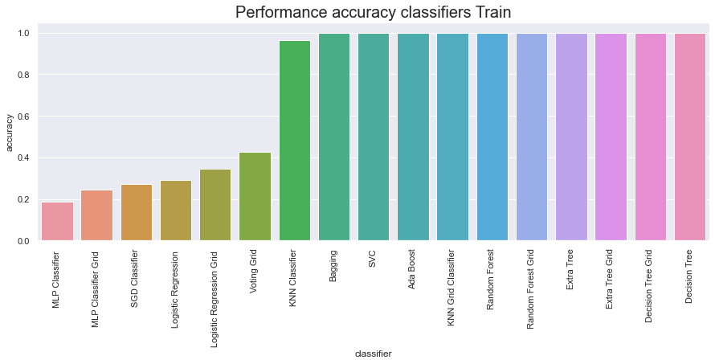

```python
plt.figure(figsize=(15,5))
a = score_df_train.sort_values(by = 'accuracy')
p = sns.barplot(x = a.classifier, y = a.accuracy)
p = plt.xticks(rotation=90)
plt.title("Performance accuracy classifiers Train", size=20)
```

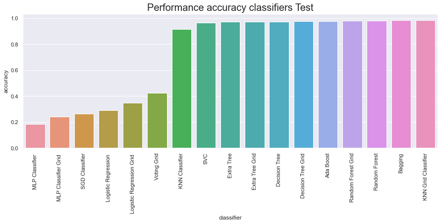

```python
plt.figure(figsize=(15,5))
a = score_df_test.sort_values(by = 'accuracy')
p = sns.barplot(x = a.classifier, y = a.accuracy)
p = plt.xticks(rotation=90)
plt.title("Performance accuracy classifiers Test", size=20)
```

Dall'accuracy emerge che 11 classificatori su 17 proposti ottengono dei buoni risultati, i due migliori risultano essere KNN Grid e Bagging per pochissimi punti rispetto agli altri tra questi 11. Il peggiore è MLP classifier che ottiene uno score davvero basso, come del resto SGD classifier, LogisticRegression, e Voting classifier.

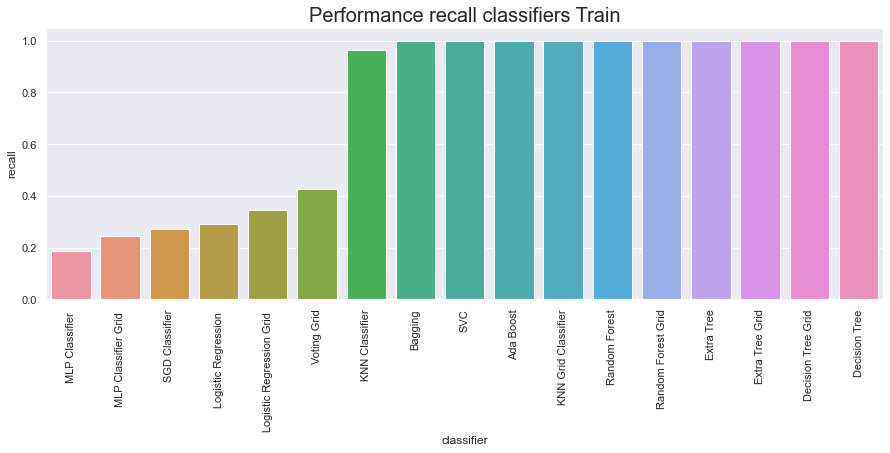

```python
plt.figure(figsize=(15,5))
a = score_df_train.sort_values(by = 'recall')
p = sns.barplot(x = a.classifier, y = a.recall)
p = plt.xticks(rotation=90)
plt.title("Performance recall classifiers Train", size=20)
```

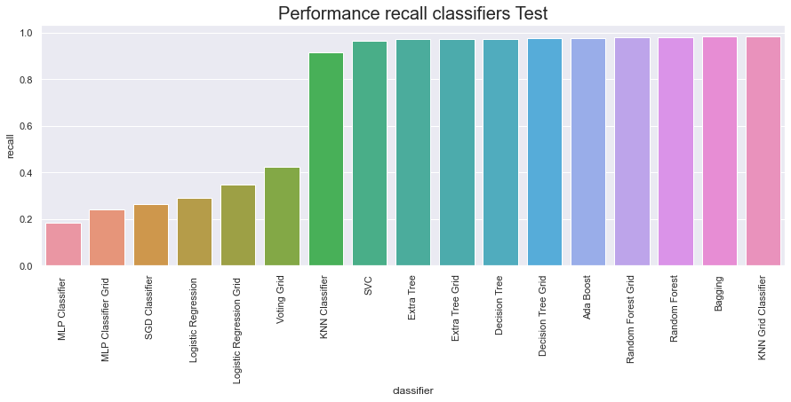

```python
plt.figure(figsize=(15,5))
a = score_df_test.sort_values(by = 'recall')
p = sns.barplot(x = a.classifier, y = a.recall)
p = plt.xticks(rotation=90)
plt.title("Performance recall classifiers Test", size=20)
```

Le analisi sulla recall confermano quanto detto in precedenza, ciò vuol dire che pochi record della classe "positiva" sono stati classificati come "negativi".

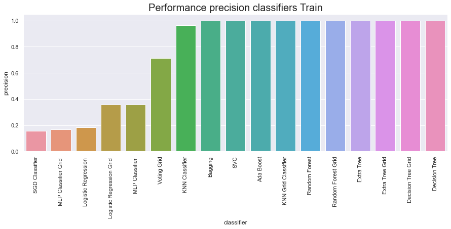

```python
plt.figure(figsize=(15,5))
a = score_df_train.sort_values(by = 'precision')
p = sns.barplot(x = a.classifier, y = a.precision)
p = plt.xticks(rotation=90)
plt.title("Performance precision classifiers Train", size=20)
```

[figure not shown]

```python
plt.figure(figsize=(15,5))
a = score_df_test.sort_values(by = 'precision')
p = sns.barplot(x = a.classifier, y = a.precision)
p = plt.xticks(rotation=90)
plt.title("Performance precision classifiers Train", size=20)
```

Anche i valori della precision sono buoni per alcuni, mentre pessimi per altri.

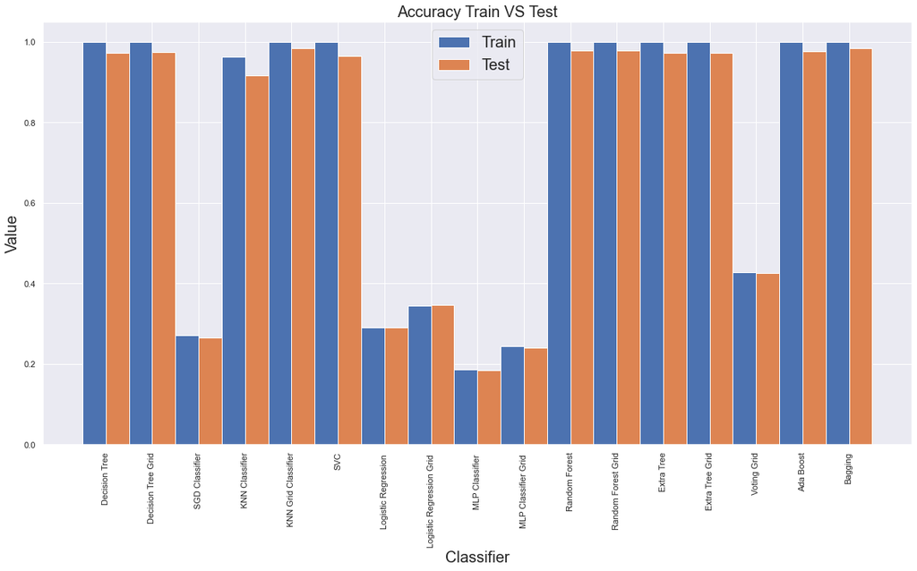

```python
train_accuracy = score_df_train.accuracy.values.tolist()
test_accuracy = score_df_test.accuracy.values.tolist()

fig, ax = plt.subplots(figsize=(20,10))
width = 0.50
i = np.arange(len(train_accuracy))
train_bars = ax.bar(i, train_accuracy , width,)
test_bars = ax.bar(i+width, test_accuracy , width)

ax.set_xlabel("Classifier",fontsize=20)

ax.set_ylabel('Value',fontsize=20)
ax.set_title('Accuracy Train VS Test',fontsize=20)
ax.set_xticklabels(score_df_train.classifier, rotation = 90)
ax.set_xticks(i + width / 2)

ax.legend((train_bars,test_bars),('Train','Test'),fontsize=20)
plt.show()
```

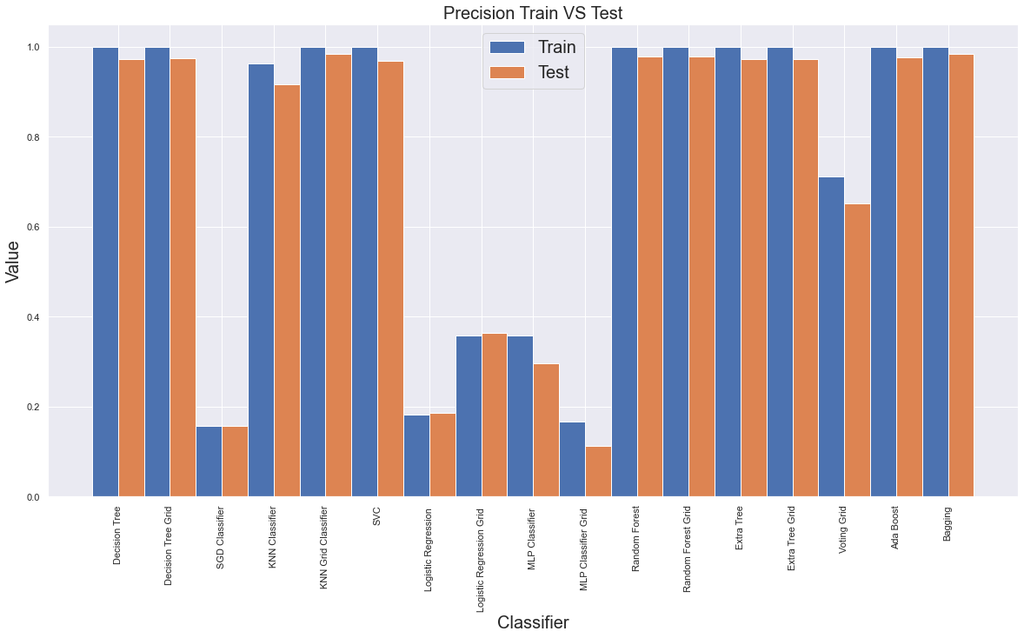

```python
train_precision = score_df_train.precision.values.tolist()
test_precision = score_df_test.precision.values.tolist()

fig, ax = plt.subplots(figsize=(20,10))
width = 0.50
i = np.arange(len(train_precision))
train_bars = ax.bar(i, train_precision , width,)
test_bars = ax.bar(i+width, test_precision , width)

ax.set_xlabel("Classifier",fontsize=20)

ax.set_ylabel('Value',fontsize=20)
ax.set_title('Precision Train VS Test',fontsize=20)
ax.set_xticklabels(score_df_train.classifier, rotation = 90)
ax.set_xticks(i + width / 2)

ax.legend((train_bars,test_bars),('Train','Test'),fontsize=20)
plt.show()
```

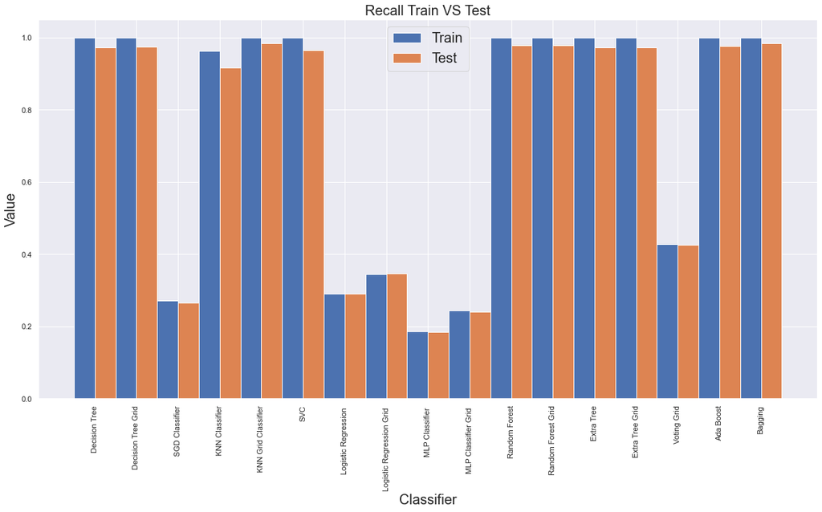

```python
train_recall = score_df_train.recall.values.tolist()
test_recall = score_df_test.recall.values.tolist()

fig, ax = plt.subplots(figsize=(20,10))
width = 0.50
i = np.arange(len(train_recall))
train_bars = ax.bar(i, train_recall , width,)
test_bars = ax.bar(i+width, test_recall , width)

ax.set_xlabel("Classifier",fontsize=20)

ax.set_ylabel('Value',fontsize=20)
ax.set_title('Recall Train VS Test',fontsize=20)
ax.set_xticklabels(score_df_train.classifier, rotation = 90)
ax.set_xticks(i + width / 2)

ax.legend((train_bars,test_bars),('Train','Test'),fontsize=20)
plt.show()
```

Come confermato dai valori di accuracy, precision e recall, i migliori classificatori risultano essere: KNN, Bagging, Random Forest, Random Forest Grid, Ada Boost, Decision Tree Grid, Decision Tree, Extra Tree Grid, SVC. Grazie a questi è possibile predire la categoria di appartenenza di un video.